# Teacher Educators’ Self-Efficacy and Attributional Beliefs as Predictors Social Support for Mentees

- Show All Code
- Hide All Code
- View Source

A Vignette Study

Author

Affiliation

David Simon

DIPF | Leibniz Institute for Research and Information in Education

Published

20 October 2026

## Information

Unfold code to see information:

```r
# Input: b_sab_mzp2_2024_R_data_file.csv
#
# Output: --
#
# Contents: (1) Read Data
#           (2) Measures
#           (3) Results

####  ------------- Load Packages ------------- ####
library(here)           # find files
library(tidyverse)      # data management
library(psych)          # scale construction, CFA
library(semTools)       # reliability
library(naniar)         # missing data
library(finalfit)       # descriptive statistics
library(corrtable)      # correlation table
library(lavaan)         # path analysis
library(patchwork)      # plot
```

## Data Analysis

### 1 Read Data

Only data from those who participated in the vignette experiment was used.

```r
data_t2 <- read.csv(here("01_data/b_sab_mzp2_2024_data_file.csv")) %>%
  dplyr::filter(vig == 1 | vig == 2 | vig == 3)
```

### 2 Measures

#### 2.1 Confirmatory Factor Analysis (CFA): Social Support Scales

Items measuring social supports were developed aligning with Richter at al. (2011), Schulz and Schwarzer (2003), and our theoretical understanding of social support. We adapted the perspective to that of the educators (social support providers). Five items were created for each dimension of social support. The factorial structure of three dimensions was tested calculating a confirmatory factor analysis.

Data for CFA:

```r
data_cfa_1 <- data_t2 %>%
  dplyr::select(sozunt_ins5:sozunt_ins2)
```

Describe data:

```r
data_cfa_1_sorted <- data_cfa_1[, sort(colnames(data_cfa_1))]
psych::describe(data_cfa_1_sorted)
```

```
            vars   n mean   sd median trimmed  mad min max range  skew kurtosis
sozunt_emo1    1 141 3.47 1.72      4    3.46 2.97   1   6     5  0.05    -1.32
sozunt_emo2    2 142 5.40 1.00      6    5.61 0.00   1   6     5 -2.15     5.18
sozunt_emo3    3 140 5.34 0.90      6    5.49 0.00   1   6     5 -1.65     3.61
sozunt_emo4    4 140 5.46 0.85      6    5.63 0.00   2   6     4 -1.73     2.97
sozunt_emo5    5 141 5.36 0.91      6    5.54 0.00   1   6     5 -2.22     6.84
sozunt_inf1    6 138 4.54 1.82      5    4.78 1.48   1   6     5 -0.98    -0.50
sozunt_inf2    7 139 4.65 1.28      5    4.81 1.48   1   6     5 -0.92     0.35
sozunt_inf3    8 142 5.15 1.11      5    5.36 1.48   1   6     5 -1.59     2.45
sozunt_inf4    9 141 5.75 0.58      6    5.88 0.00   2   6     4 -3.07    12.79
sozunt_inf5   10 139 5.34 1.07      6    5.55 0.00   1   6     5 -1.98     4.25
sozunt_ins1   11 139 2.62 1.53      2    2.49 1.48   1   6     5  0.48    -1.01
sozunt_ins2   12 139 4.01 1.49      4    4.10 1.48   1   6     5 -0.43    -0.87
sozunt_ins3   13 140 3.36 1.69      3    3.32 2.97   1   6     5 -0.02    -1.37
sozunt_ins4   14 138 3.62 1.79      4    3.65 2.97   1   6     5 -0.19    -1.39
sozunt_ins5   15 139 1.83 1.32      1    1.56 0.00   1   6     5  1.67     1.85
              se
sozunt_emo1 0.15
sozunt_emo2 0.08
sozunt_emo3 0.08
sozunt_emo4 0.07
sozunt_emo5 0.08
sozunt_inf1 0.15
sozunt_inf2 0.11
sozunt_inf3 0.09
sozunt_inf4 0.05
sozunt_inf5 0.09
sozunt_ins1 0.13
sozunt_ins2 0.13
sozunt_ins3 0.14
sozunt_ins4 0.15
sozunt_ins5 0.11
```

*Step 1: Fitting a Three-factor Model*

```r
# specify the model
cfa_model_ss <- ' inf =~ sozunt_inf1 + sozunt_inf2 + sozunt_inf3 + sozunt_inf4 +
                         sozunt_inf5
                  emo =~ sozunt_emo1 + sozunt_emo2 + sozunt_emo3 + sozunt_emo4 +
                         sozunt_emo5
                  ins =~ sozunt_ins1 + sozunt_ins2 + sozunt_ins3 + sozunt_ins4 +
                         sozunt_ins5 '

# fit the model
fit_cfa_ss <- lavaan::cfa(cfa_model_ss,
                          data = data_cfa_1,
                          ordered = TRUE,
                          estimator = "DWLS",
                          test = "scaled.shifted",
                          missing = "pairwise")

# evaluate the model
summary(fit_cfa_ss, standardized = TRUE, fit.measures = TRUE)
```

```
lavaan 0.6-21 ended normally after 39 iterations

  Estimator                                       DWLS
  Optimization method                           NLMINB
  Number of model parameters                        89

                                                  Used       Total
  Number of observations                           143         176
  Number of missing patterns                        16

Model Test User Model:
                                              Standard      Scaled
  Test Statistic                               160.268     173.036
  Degrees of freedom                                87          87
  P-value (Unknown)                                 NA       0.000
  Scaling correction factor                                  1.111
  Shift parameter                                           28.752
    simple second-order correction

Model Test Baseline Model:

  Test statistic                              1518.079     875.790
  Degrees of freedom                               105         105
  P-value                                           NA       0.000
  Scaling correction factor                                  1.833

User Model versus Baseline Model:

  Comparative Fit Index (CFI)                    0.948       0.888
  Tucker-Lewis Index (TLI)                       0.937       0.865

  Robust Comparative Fit Index (CFI)                         0.684
  Robust Tucker-Lewis Index (TLI)                            0.619

Root Mean Square Error of Approximation:

  RMSEA                                          0.077       0.083
  90 Percent confidence interval - lower         0.058       0.065
  90 Percent confidence interval - upper         0.096       0.102
  P-value H_0: RMSEA <= 0.050                    0.012       0.002
```

[output cut: 127 more lines]

```
   .sozunt_inf4       0.377                               0.377    0.377
   .sozunt_inf5       0.523                               0.523    0.523
   .sozunt_emo1       0.877                               0.877    0.877
   .sozunt_emo2       0.606                               0.606    0.606
   .sozunt_emo3       0.483                               0.483    0.483
   .sozunt_emo4       0.403                               0.403    0.403
   .sozunt_emo5       0.577                               0.577    0.577
   .sozunt_ins1       0.468                               0.468    0.468
   .sozunt_ins2       0.757                               0.757    0.757
   .sozunt_ins3       0.831                               0.831    0.831
   .sozunt_ins4       0.954                               0.954    0.954
   .sozunt_ins5       0.857                               0.857    0.857
    inf               0.319    0.081    3.932    0.000    1.000    1.000
    emo               0.123    0.060    2.042    0.041    1.000    1.000
    ins               0.532    0.142    3.742    0.000    1.000    1.000
```

Model fit was poor:

```r
# CFI cut-off: > .95; SRMR cut-off: < .08; RMSEA cut-off: < .06
lavaan::fitmeasures(fit_cfa_ss, c("cfi.scaled", "rmsea.scaled", "srmr"))
```

```
  cfi.scaled rmsea.scaled         srmr
       0.888        0.083        0.100
```

Since factor loadings of on the instrumental support factor `ins` were low for several items, we operationalized instrumental support based on the three highest-loading items `sozunt_ins1`, `sozunt_ins2`, `sozunt_ins3`, which are closely aligned with the theoretical notion of providing material, and reran the CFA. Subsequently, `sozunt_emo1` was also discarded because of the low factor loading. The subsequent model is as follows:

```r
# specify the model
cfa_model_ss_2 <- ' inf =~ sozunt_inf1 + sozunt_inf2 + sozunt_inf3 + sozunt_inf4 +
                           sozunt_inf5
                    emo =~ sozunt_emo2 + sozunt_emo3 + sozunt_emo4 +
                           sozunt_emo5
                    ins =~ sozunt_ins1 + sozunt_ins2 + sozunt_ins3 '

# fit the model
fit_cfa_ss_2 <- lavaan::cfa(cfa_model_ss_2,
                            data = data_cfa_1,
                            ordered = TRUE,
                            estimator = "DWLS",
                            test = "scaled.shifted",
                            missing = "pairwise")

# evaluate the model
summary(fit_cfa_ss_2, standardized = TRUE, fit.measures = TRUE)
```

```
lavaan 0.6-21 ended normally after 32 iterations

  Estimator                                       DWLS
  Optimization method                           NLMINB
  Number of model parameters                        71

                                                  Used       Total
  Number of observations                           143         176
  Number of missing patterns                        14

Model Test User Model:
                                              Standard      Scaled
  Test Statistic                                55.299      77.323
  Degrees of freedom                                51          51
  P-value (Unknown)                                 NA       0.010
  Scaling correction factor                                  0.843
  Shift parameter                                           11.757
    simple second-order correction

Model Test Baseline Model:

  Test statistic                              1329.376     798.910
  Degrees of freedom                                66          66
  P-value                                           NA       0.000
  Scaling correction factor                                  1.724

User Model versus Baseline Model:

  Comparative Fit Index (CFI)                    0.997       0.964
  Tucker-Lewis Index (TLI)                       0.996       0.954

  Robust Comparative Fit Index (CFI)                         0.787
  Robust Tucker-Lewis Index (TLI)                            0.725

Root Mean Square Error of Approximation:

  RMSEA                                          0.024       0.060
  90 Percent confidence interval - lower         0.000       0.030
  90 Percent confidence interval - upper         0.061       0.086
  P-value H_0: RMSEA <= 0.050                    0.855       0.255
```

[output cut: 106 more lines]

```
   .sozunt_inf1       0.691                               0.691    0.691
   .sozunt_inf2       0.553                               0.553    0.553
   .sozunt_inf3       0.358                               0.358    0.358
   .sozunt_inf4       0.375                               0.375    0.375
   .sozunt_inf5       0.514                               0.514    0.514
   .sozunt_emo2       0.602                               0.602    0.602
   .sozunt_emo3       0.478                               0.478    0.478
   .sozunt_emo4       0.389                               0.389    0.389
   .sozunt_emo5       0.549                               0.549    0.549
   .sozunt_ins1       0.761                               0.761    0.761
   .sozunt_ins2       0.826                               0.826    0.826
   .sozunt_ins3       0.797                               0.797    0.797
    inf               0.309    0.081    3.825    0.000    1.000    1.000
    emo               0.398    0.074    5.406    0.000    1.000    1.000
    ins               0.239    0.107    2.236    0.025    1.000    1.000
```

Model fit was acceptable:

```r
# CFI cut-off: > .95; SRMR cut-off: < .08; RMSEA cut-off: < .06
lavaan::fitmeasures(fit_cfa_ss_2, c("cfi.scaled", "rmsea.scaled", "srmr", "cfi.robust", "rmsea.robust"))
```

```
  cfi.scaled rmsea.scaled         srmr   cfi.robust rmsea.robust
       0.964        0.060        0.073        0.787        0.140
```

*Step 2: Evaluating Reliability (omega)*

```r
compRelSEM(fit_cfa_ss_2)
```

```
  inf   emo   ins
0.731 0.719 0.404
```

*Step 3: Interpretation of factors*

We proceeded with the following model:

- Factor 1: Informational support (“Tips and advice”) was best represented through the items `sozunt_inf1`, `sozunt_inf2`, `sozunt_inf3`, `sozunt_inf4` and `sozunt_inf5`.
- Factor 2: Emotional support (“Comfort and nearness”) was best represented through the items `sozunt_emo2`, `sozunt_emo3`, `sozunt_emo4` and `sozunt_emo5`.
- Factor 3: Instrumental support (“Provision of goods and materials”) was best represented through the items `sozunt_ins1`, `sozunt_ins2` and `sozunt_ins3`.

#### 2.2 Confirmatory Factor Analysis (CFA): Teacher Mentoring Self-Efficacy

Tickell and Klassen (2024) developed a scale for measuring teacher mentoring self-efficacy beliefs and suggest a two-factor model, with factors named as *Pedagogical Practices* and *Professional Relationships*. We tested this factor structure in our German translation of the questionnaire:

Data for CFA:

```r
data_cfa_2 <- data_t2 %>%
  dplyr::select(seffsab_1:seffsab_9)
```

Describe data:

```r
describe(data_cfa_2)
```

```
           vars   n mean   sd median trimmed  mad min max range  skew kurtosis
seffsab_1     1 139 3.79 0.41      4    3.86 0.00   3   4     1 -1.42     0.01
seffsab_2     2 139 3.51 0.54      4    3.54 0.00   2   4     2 -0.45    -1.01
seffsab_20    3 139 3.79 0.43      4    3.87 0.00   2   4     2 -1.70     1.64
seffsab_14    4 137 3.11 0.66      3    3.14 0.00   1   4     3 -0.27    -0.19
seffsab_6     5 137 3.63 0.53      4    3.68 0.00   2   4     2 -0.96    -0.22
seffsab_28    6 138 3.55 0.57      4    3.61 0.00   2   4     2 -0.79    -0.42
seffsab_48    7 136 3.02 0.86      3    3.09 1.48   1   4     3 -0.53    -0.44
seffsab_39    8 139 3.41 0.57      3    3.44 0.00   2   4     2 -0.33    -0.81
seffsab_46    9 138 3.52 0.56      4    3.56 0.00   2   4     2 -0.59    -0.75
seffsab_47   10 139 3.49 0.61      4    3.56 0.00   2   4     2 -0.73    -0.46
seffsab_4    11 138 3.58 0.52      4    3.62 0.00   2   4     2 -0.62    -0.97
seffsab_29   12 136 3.32 0.70      3    3.40 1.48   1   4     3 -0.64    -0.26
seffsab_44   13 139 3.71 0.46      4    3.75 0.00   3   4     1 -0.89    -1.22
seffsab_27   14 139 3.71 0.45      4    3.76 0.00   3   4     1 -0.93    -1.15
seffsab_43   15 138 3.58 0.55      4    3.63 0.00   2   4     2 -0.83    -0.40
seffsab_9    16 139 3.86 0.37      4    3.95 0.00   2   4     2 -2.42     5.09
             se
seffsab_1  0.03
seffsab_2  0.05
seffsab_20 0.04
seffsab_14 0.06
seffsab_6  0.05
seffsab_28 0.05
seffsab_48 0.07
seffsab_39 0.05
seffsab_46 0.05
seffsab_47 0.05
seffsab_4  0.04
seffsab_29 0.06
seffsab_44 0.04
seffsab_27 0.04
seffsab_43 0.05
seffsab_9  0.03
```

*Step 1: Fitting a Two-factor Model*

```r
# specify the model
cfa_model_se <- ' pae =~ seffsab_1 + seffsab_2 + seffsab_20 + seffsab_14 +
                         seffsab_6 + seffsab_28 + seffsab_48 + seffsab_39 +
                         seffsab_46 + seffsab_47 + seffsab_4
                  rel =~ seffsab_29 + seffsab_44 + seffsab_27 + seffsab_43 +
                         seffsab_9 '

# fit the model
fit_cfa_se <- lavaan::cfa(cfa_model_se,
                          data = data_cfa_2,
                          ordered = TRUE,
                          estimator = "DWLS",
                          test = "scaled.shifted",
                          missing = "pairwise")

# evaluate the model
summary(fit_cfa_se, standardized = TRUE, fit.measures = TRUE)
```

```
lavaan 0.6-21 ended normally after 30 iterations

  Estimator                                       DWLS
  Optimization method                           NLMINB
  Number of model parameters                        49

                                                  Used       Total
  Number of observations                           139         153
  Number of missing patterns                         7

Model Test User Model:
                                              Standard      Scaled
  Test Statistic                               162.538     183.430
  Degrees of freedom                               103         103
  P-value (Unknown)                                 NA       0.000
  Scaling correction factor                                  1.138
  Shift parameter                                           40.548
    simple second-order correction

Model Test Baseline Model:

  Test statistic                              2813.845    1489.006
  Degrees of freedom                               120         120
  P-value                                           NA       0.000
  Scaling correction factor                                  1.968

User Model versus Baseline Model:

  Comparative Fit Index (CFI)                    0.978       0.941
  Tucker-Lewis Index (TLI)                       0.974       0.932

  Robust Comparative Fit Index (CFI)                            NA
  Robust Tucker-Lewis Index (TLI)                               NA

Root Mean Square Error of Approximation:

  RMSEA                                          0.065       0.075
  90 Percent confidence interval - lower         0.045       0.057
  90 Percent confidence interval - upper         0.083       0.093
  P-value H_0: RMSEA <= 0.050                    0.103       0.013
```

[output cut: 85 more lines]

```
   .seffsab_14        0.620                               0.620    0.620
   .seffsab_6         0.408                               0.408    0.408
   .seffsab_28        0.770                               0.770    0.770
   .seffsab_48        0.767                               0.767    0.767
   .seffsab_39        0.528                               0.528    0.528
   .seffsab_46        0.575                               0.575    0.575
   .seffsab_47        0.717                               0.717    0.717
   .seffsab_4         0.420                               0.420    0.420
   .seffsab_29        0.677                               0.677    0.677
   .seffsab_44        0.181                               0.181    0.181
   .seffsab_27        0.157                               0.157    0.157
   .seffsab_43        0.523                               0.523    0.523
   .seffsab_9         0.363                               0.363    0.363
    pae               0.601    0.110    5.463    0.000    1.000    1.000
    rel               0.323    0.057    5.698    0.000    1.000    1.000
```

Model fit was poor:

```r
# CFI cut-off: > .95; SRMR cut-off: < .08; RMSEA cut-off: < .06
lavaan::fitMeasures(fit_cfa_se, c("cfi.scaled", "rmsea.scaled", "srmr"))
```

```
  cfi.scaled rmsea.scaled         srmr
       0.941        0.075        0.103
```

Evaluating modification indices:

```r
inspect_fit_cfa_se <- lavaan::modindices(fit_cfa_se, sort = TRUE, minimum.value = 10)

inspect_fit_cfa_se
```

```
           lhs op        rhs     mi   epc sepc.lv sepc.all sepc.nox
193 seffsab_48 ~~ seffsab_39 35.104 0.416   0.416    0.653    0.653
104        pae =~ seffsab_27 19.064 1.299   1.007    1.007    1.007
118  seffsab_1 ~~  seffsab_2 14.612 0.364   0.364    0.731    0.731
```

- `seffsab_48` was removed (justified by similarity of content with `seffsab_39`, which in contrast covered the construct better)

We reran the CFA:

```r
# specify the model
cfa_model_se_2 <- ' pae =~ seffsab_1 + seffsab_2 + seffsab_20 + seffsab_14 +
                           seffsab_6 + seffsab_28 + seffsab_39 +
                           seffsab_46 + seffsab_47 + seffsab_4
                    rel =~ seffsab_29 + seffsab_44 + seffsab_27 + seffsab_43 +
                           seffsab_9 '

# fit the model
fit_cfa_se_2 <- lavaan::cfa(cfa_model_se_2,
                            data = data_cfa_2,
                            ordered = TRUE,
                            estimator = "DWLS",
                            test = "scaled.shifted",
                            missing = "pairwise")

# evaluate the model
summary(fit_cfa_se_2, standardized = TRUE, fit.measures = TRUE)
```

```
lavaan 0.6-21 ended normally after 30 iterations

  Estimator                                       DWLS
  Optimization method                           NLMINB
  Number of model parameters                        45

                                                  Used       Total
  Number of observations                           139         153
  Number of missing patterns                         5

Model Test User Model:
                                              Standard      Scaled
  Test Statistic                               112.775     137.421
  Degrees of freedom                                89          89
  P-value (Unknown)                                 NA       0.001
  Scaling correction factor                                  1.076
  Shift parameter                                           32.595
    simple second-order correction

Model Test Baseline Model:

  Test statistic                              2607.412    1409.418
  Degrees of freedom                               105         105
  P-value                                           NA       0.000
  Scaling correction factor                                  1.918

User Model versus Baseline Model:

  Comparative Fit Index (CFI)                    0.990       0.963
  Tucker-Lewis Index (TLI)                       0.989       0.956

  Robust Comparative Fit Index (CFI)                            NA
  Robust Tucker-Lewis Index (TLI)                               NA

Root Mean Square Error of Approximation:

  RMSEA                                          0.044       0.063
  90 Percent confidence interval - lower         0.007       0.041
  90 Percent confidence interval - upper         0.067       0.083
  P-value H_0: RMSEA <= 0.050                    0.641       0.153
```

[output cut: 80 more lines]

```
   .seffsab_20        0.531                               0.531    0.531
   .seffsab_14        0.617                               0.617    0.617
   .seffsab_6         0.402                               0.402    0.402
   .seffsab_28        0.764                               0.764    0.764
   .seffsab_39        0.626                               0.626    0.626
   .seffsab_46        0.578                               0.578    0.578
   .seffsab_47        0.691                               0.691    0.691
   .seffsab_4         0.402                               0.402    0.402
   .seffsab_29        0.679                               0.679    0.679
   .seffsab_44        0.188                               0.188    0.188
   .seffsab_27        0.151                               0.151    0.151
   .seffsab_43        0.521                               0.521    0.521
   .seffsab_9         0.362                               0.362    0.362
    pae               0.611    0.111    5.521    0.000    1.000    1.000
    rel               0.321    0.057    5.635    0.000    1.000    1.000
```

Model fit was still not as good as desired:

```r
# CFI cut-off: > .95; SRMR cut-off: < .08; RMSEA cut-off: < .06
fitMeasures(fit_cfa_se_2, c("cfi.scaled", "rmsea.scaled", "srmr"))
```

```
  cfi.scaled rmsea.scaled         srmr
       0.963        0.063        0.096
```

Evaluating modification indices again:

```r
inspect_fit_cfa_se_2 <- lavaan::modindices(fit_cfa_se_2, sort = TRUE, minimum.value = 10)

inspect_fit_cfa_se_2
```

```
          lhs op        rhs     mi   epc sepc.lv sepc.all sepc.nox
97        pae =~ seffsab_27 20.093 1.373   1.073    1.073    1.073
110 seffsab_1 ~~  seffsab_2 13.315 0.350   0.350    0.724    0.724
```

- `seffsab_2` was removed (justified by similarity of content with `seffsab_1`, which in contrast covered the construct better)
- `seffsab_27` was removed (justified by ambiguity with regard to both factors)

We reran the CFA:

```r
# specify the model
cfa_model_se_3 <- ' pae =~ seffsab_1 + seffsab_20 + seffsab_14 +
                           seffsab_6 + seffsab_28 + seffsab_39 +
                           seffsab_46 + seffsab_47 + seffsab_4
                    rel =~ seffsab_29 + seffsab_44 + seffsab_43 +
                           seffsab_9 '

# fit the model
fit_cfa_se_3 <- lavaan::cfa(cfa_model_se_3,
                            data = data_cfa_2,
                            ordered = TRUE,
                            estimator = "DWLS",
                            test = "scaled.shifted",
                            missing = "pairwise")

# evaluate the model
summary(fit_cfa_se_3, standardized = TRUE, fit.measures = TRUE)
```

```
lavaan 0.6-21 ended normally after 26 iterations

  Estimator                                       DWLS
  Optimization method                           NLMINB
  Number of model parameters                        40

                                                  Used       Total
  Number of observations                           139         153
  Number of missing patterns                         5

Model Test User Model:
                                              Standard      Scaled
  Test Statistic                                60.699      79.785
  Degrees of freedom                                64          64
  P-value (Unknown)                                 NA       0.088
  Scaling correction factor                                  1.022
  Shift parameter                                           20.397
    simple second-order correction

Model Test Baseline Model:

  Test statistic                              1761.111    1038.390
  Degrees of freedom                                78          78
  P-value                                           NA       0.000
  Scaling correction factor                                  1.753

User Model versus Baseline Model:

  Comparative Fit Index (CFI)                    1.000       0.984
  Tucker-Lewis Index (TLI)                       1.002       0.980

  Robust Comparative Fit Index (CFI)                            NA
  Robust Tucker-Lewis Index (TLI)                               NA

Root Mean Square Error of Approximation:

  RMSEA                                          0.000       0.042
  90 Percent confidence interval - lower         0.000       0.000
  90 Percent confidence interval - upper         0.046       0.070
  P-value H_0: RMSEA <= 0.050                    0.969       0.649
```

[output cut: 73 more lines]

```
   .seffsab_1         0.464                               0.464    0.464
   .seffsab_20        0.578                               0.578    0.578
   .seffsab_14        0.575                               0.575    0.575
   .seffsab_6         0.368                               0.368    0.368
   .seffsab_28        0.748                               0.748    0.748
   .seffsab_39        0.574                               0.574    0.574
   .seffsab_46        0.576                               0.576    0.576
   .seffsab_47        0.713                               0.713    0.713
   .seffsab_4         0.438                               0.438    0.438
   .seffsab_29        0.675                               0.675    0.675
   .seffsab_44        0.108                               0.108    0.108
   .seffsab_43        0.439                               0.439    0.439
   .seffsab_9         0.303                               0.303    0.303
    pae               0.536    0.111    4.824    0.000    1.000    1.000
    rel               0.325    0.058    5.556    0.000    1.000    1.000
```

Model fit improved:

```r
# CFI cut-off: > .95; SRMR cut-off: < .08; RMSEA cut-off: < .06
fitMeasures(fit_cfa_se_3, c("cfi.scaled", "rmsea.scaled", "srmr"))
```

```
  cfi.scaled rmsea.scaled         srmr
       0.984        0.042        0.085
```

*Step 2: Evaluating Reliability (Omega)*

Both scales showed acceptable reliability:

```r
compRelSEM(fit_cfa_se_3)
```

```
  pae   rel
0.804 0.713
```

*Step 3: Contrasting a One-factor Model*

```r
# specify the model
cfa_model_se_4 <- ' sef =~ seffsab_1 + seffsab_20 + seffsab_14 +
                           seffsab_6 + seffsab_28 + seffsab_39 +
                           seffsab_46 + seffsab_47 + seffsab_4 +
                           seffsab_29 + seffsab_44 + seffsab_43 +
                           seffsab_9 '

# fit the model
fit_cfa_se_4 <- lavaan::cfa(cfa_model_se_4,
                            data = data_cfa_2,
                            ordered = TRUE,
                            estimator = "DWLS",
                            test = "scaled.shifted",
                            missing = "pairwise")
```

Model fit:

```r
# CFI cut-off: .95; SRMR cut-off: .09
fitMeasures(fit_cfa_se_4, c("cfi.scaled", "rmsea.scaled", "srmr"))
```

```
  cfi.scaled rmsea.scaled         srmr
       0.949        0.074        0.105
```

Compare to two-factor-model:

```r
anova(fit_cfa_se_3, fit_cfa_se_4)
```

```
Scaled Chi-Squared Difference Test (method = "satorra.2000")

lavaan->lavTestLRT():
   lavaan NOTE: The "Chisq" column contains standard test statistics, not the
   robust test that should be reported per model. A robust difference test is
   a function of two standard (not robust) statistics.

             Df AIC BIC  Chisq Chisq diff Df diff Pr(>Chisq)
fit_cfa_se_3 64         60.699
fit_cfa_se_4 65         97.195     16.499       1  4.867e-05 ***
---
Signif. codes:  0 '***' 0.001 '**' 0.01 '*' 0.05 '.' 0.1 ' ' 1
```

The Two-factor Model describes the data better.

#### 2.3 Compute Scale Scores

Unfold code to see scale construction:

```r
data <- data_t2

## Vignette as factor
data$vig <- as.factor(data$vig)

## Attribution

data <- data %>%
  dplyr::mutate(int = int_1,  # Internality
                sta = sta_1,  # Stability
                con = kon_1)  # Controllability

## Social Support

# Informational support
data <- data %>%
  dplyr::mutate(inf_sup = rowMeans(subset(data, select = c(sozunt_inf1,
                                                           sozunt_inf2,
                                                           sozunt_inf3,
                                                           sozunt_inf4,
                                                           sozunt_inf5)),
                                   na.rm = TRUE),

# Emotional support
                emo_sup = rowMeans(subset(data, select = c(sozunt_emo2,
                                                           sozunt_emo3,
                                                           sozunt_emo4,
                                                           sozunt_emo5)),
                                   na.rm = TRUE),
# Instrumental Support
                ins_sup = rowMeans(subset(data, select = c(sozunt_ins1,
                                                           sozunt_ins2,
                                                           sozunt_ins3)),
                                   na.rm = TRUE))

## Teacher Mentoring Self-Efficacy

# Pedagogical Practices
data <- data %>%
  dplyr::mutate(sef_pea = rowMeans(subset(data, select = c(seffsab_1, seffsab_20,
                                                           seffsab_14, seffsab_6,
                                                           seffsab_28, seffsab_39,
                                                           seffsab_46, seffsab_47,
                                                           seffsab_4)),
                                   na.rm = TRUE),

# Professional Relationships
                sef_rel = rowMeans(subset(data, select = c(seffsab_29, seffsab_44,
                                                           seffsab_43, seffsab_9)),
                                   na.rm = TRUE))
```

#### 2.4 Glossary

*Attributions*  
adapted from (Steinsmeier et al., 1985)

*Social Support*  
adapted from (Richter et al., 2011)

- `inf_sup`: Informational support
- `emo_sup`: Emotional support
- `ins_sup`: Instrumental support

*Self-Efficacy*  
adapted from (Tickell & Klassen, 2024)

- `sef_pea`: Pedagogical Practices
- `sef_rel`: Professional Relationships

### 3 Results

#### 3.1 Sample

```r
data_sam <- data %>%
  dplyr::select(id, age, exp)

finalfit::ff_glimpse(data_sam, digits = 2)
```

```
$Continuous
    label var_type   n missing_n missing_percent  mean   sd   min quartile_25
age   age    <int> 134        19           12.42 49.81 7.96 33.00       43.00
exp   exp    <dbl> 132        21           13.73  9.34 5.23  1.00        5.00
    median quartile_75   max
age  51.00       56.00 65.00
exp   8.50       13.00 24.00

$Categorical
   label var_type   n missing_n missing_percent levels_n levels levels_count
id    id    <chr> 153         0            0.00      153      -            -
   levels_percent
id              -
```

```r
data_sam <- data %>%
  dplyr::select(sex) %>%
  dplyr::mutate(sex = as.factor(sex)) %>%
  filter(!is.na(sex))

finalfit::ff_glimpse(data_sam, digits = 2)
```

```
$Continuous
Dataframe mit 0 Spalten und 136 Zeilen

$Categorical
    label var_type   n missing_n missing_percent levels_n                levels
sex   sex    <fct> 136         0            0.00        2 "1", "2", "(Missing)"
    levels_count levels_percent
sex       75, 61         55, 45
```

#### 3.2 Correlation Table

```r
data_ana <- data %>%
  dplyr::select(inf_sup, emo_sup, ins_sup, int, con, sta, sef_pea, sef_rel)

corrtable::correlation_matrix(
  data_ana,
  type = "spearman",
  digits = 2,
  decimal.mark = ".",
  use = "all",
  show_significance = TRUE,
  replace_diagonal = TRUE,
  replacement = ""
)
```

```
        inf_sup    emo_sup    ins_sup    int        con        sta
inf_sup ""         " 0.46***" " 0.21*  " " 0.23** " " 0.14   " " 0.13   "
emo_sup " 0.46***" ""         " 0.25** " "-0.05   " " 0.12   " " 0.04   "
ins_sup " 0.21*  " " 0.25** " ""         "-0.13   " " 0.03   " "-0.01   "
int     " 0.23** " "-0.05   " "-0.13   " ""         " 0.35***" " 0.36***"
con     " 0.14   " " 0.12   " " 0.03   " " 0.35***" ""         " 0.25** "
sta     " 0.13   " " 0.04   " "-0.01   " " 0.36***" " 0.25** " ""
sef_pea " 0.20*  " " 0.32***" " 0.25** " " 0.01   " " 0.11   " "-0.02   "
sef_rel " 0.09   " " 0.39***" " 0.09   " " 0.02   " "-0.03   " " 0.02   "
        sef_pea    sef_rel
inf_sup " 0.20*  " " 0.09   "
emo_sup " 0.32***" " 0.39***"
ins_sup " 0.25** " " 0.09   "
int     " 0.01   " " 0.02   "
con     " 0.11   " "-0.03   "
sta     "-0.02   " " 0.02   "
sef_pea ""         " 0.52***"
sef_rel " 0.52***" ""
```

#### 3.3 Descriptive Statistics

```r
psych::describe(data_ana)
```

```
        vars   n mean   sd median trimmed  mad  min max range  skew kurtosis
inf_sup    1 143 5.10 0.82   5.20    5.20 0.89 1.20   6  4.80 -1.28     2.66
emo_sup    2 143 5.39 0.70   5.50    5.50 0.74 1.25   6  4.75 -2.23     8.28
ins_sup    3 141 3.32 1.08   3.33    3.33 0.99 1.00   6  5.00  0.03    -0.33
int        4 141 4.34 1.06   4.00    4.38 0.00 1.00   7  6.00 -0.42     1.11
con        5 141 5.89 1.12   6.00    6.03 1.48 1.00   7  6.00 -1.13     1.57
sta        6 141 5.56 1.26   6.00    5.65 1.48 2.00   7  5.00 -0.58    -0.39
sef_pea    7 139 3.54 0.33   3.56    3.56 0.33 2.67   4  1.33 -0.55    -0.48
sef_rel    8 139 3.62 0.38   3.75    3.66 0.37 2.50   4  1.50 -0.77    -0.52
          se
inf_sup 0.07
emo_sup 0.06
ins_sup 0.09
int     0.09
con     0.09
sta     0.11
sef_pea 0.03
sef_rel 0.03
```

#### 3.4 Missingness

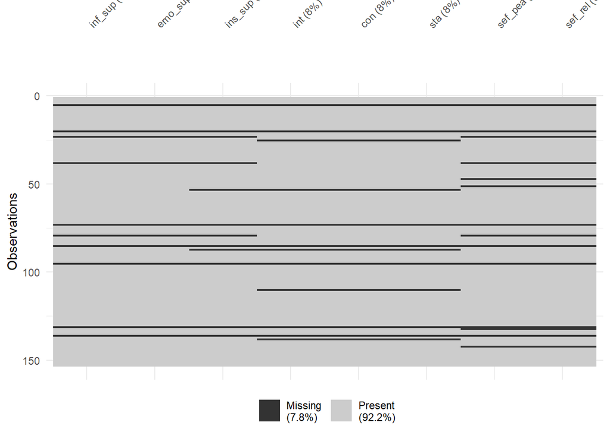

```r
naniar::vis_miss(data_ana)
```

#### 3.5 Multivariate Normality

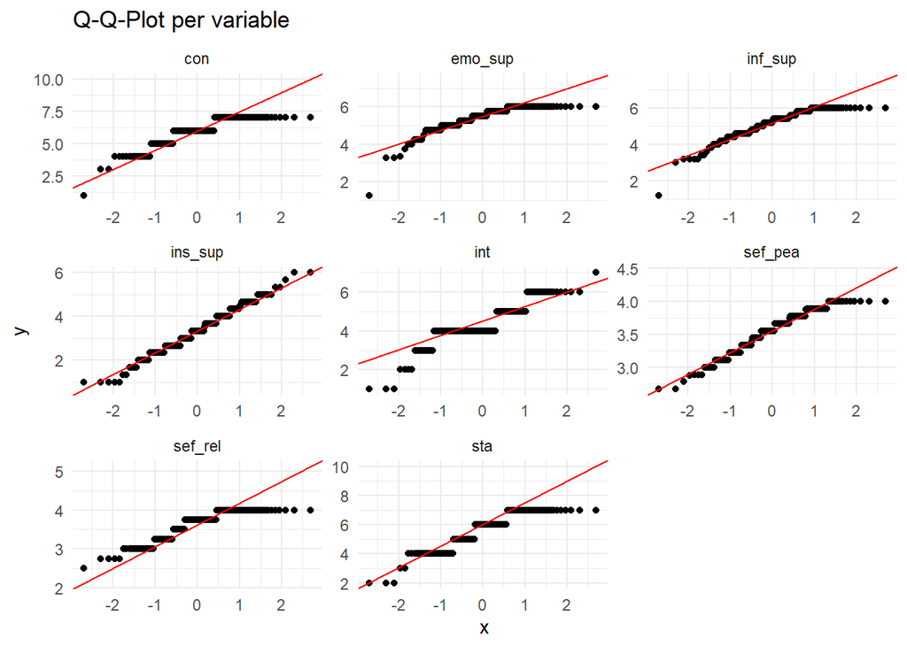

```r
# Q-Q-Plot
data_qq <- data_ana %>%
  pivot_longer(cols = everything(), names_to = "variable", values_to = "value") %>%
  filter(!is.na(value))

ggplot(data_qq, aes(sample = value)) +
  stat_qq() +
  stat_qq_line(color = "red") +
  facet_wrap(~ variable, scales = "free") +
  theme_minimal() +
  labs(title = "Q-Q-Plot per variable")
```

#### 3.6 Path Analysis

Independent variables were mean centered and standardized, before the interaction terms were calculated; dependent variables were standardized:

```r
data <- data %>%
  dplyr::select(int, con, sta, inf_sup, emo_sup, ins_sup, sef_pea, sef_rel, vig)

# mean center and standardize independent variables (z-standardize)
data$int_cntrd <- as.numeric(scale(data$int, center = TRUE, scale = TRUE))
data$sta_cntrd <- as.numeric(scale(data$sta, center = TRUE, scale = TRUE))
data$con_cntrd <- as.numeric(scale(data$con, center = TRUE, scale = TRUE))

# Interaction terms
data$conXint <- data$con_cntrd * data$int_cntrd
data$staXint <- data$sta_cntrd * data$int_cntrd

# mean center and standardize standardize dependent variables (z-standardize)
data$inf_sup <- as.numeric(scale(data$inf_sup))
data$emo_sup <- as.numeric(scale(data$emo_sup))
data$ins_sup <- as.numeric(scale(data$ins_sup))
data$sef_pea <- as.numeric(scale(data$sef_pea))
data$sef_rel <- as.numeric(scale(data$sef_rel))
```

##### 3.6.1 Test of Comparability Between Vignettes

```r
vars <- c("int","con","sta","inf_sup","emo_sup","ins_sup","sef_pea","sef_rel")

res <- lapply(vars, function(v) {
  f <- as.formula(paste(v, "~ vig"))
  w <- oneway.test(f, data = data)
  a <- aov(f, data = data)
  eta <- effectsize::eta_squared(a, partial = FALSE, ci = 0.95)
  data.frame(var = v, F = round(w$statistic, 2), df1 = round(w$parameter[1], 0),
             df2 = round(w$parameter[2], 0), p = round(w$p.value, 3),
             eta2 = round(eta$Eta2, 2))
})

do.call(rbind, res)
```

```
       var    F df1 df2     p eta2
F      int 3.23   2  91 0.044 0.05
F1     con 1.40   2  88 0.253 0.02
F2     sta 0.23   2  90 0.797 0.00
F3 inf_sup 0.61   2  90 0.545 0.01
F4 emo_sup 1.97   2  88 0.146 0.02
F5 ins_sup 0.84   2  92 0.435 0.01
F6 sef_pea 0.45   2  89 0.640 0.01
F7 sef_rel 0.08   2  89 0.926 0.00
```

```r
data <- data %>%
  mutate(vig1 = as.numeric(vig == "1"),
         vig2 = as.numeric(vig == "2"),
         vig3 = as.numeric(vig == "3"))
```

##### 3.6.2 Self-Efficacy

```r
model <- '
  inf_sup ~ sef_pea + sef_rel + vig2 + vig3
  emo_sup ~ sef_pea + sef_rel + vig2 + vig3
  ins_sup ~ sef_pea + sef_rel + vig2 + vig3

  inf_sup ~~ emo_sup
  emo_sup ~~ ins_sup
  inf_sup ~~ ins_sup
'

fit_sef <- lavaan::sem(model = model,
                       data = data,
                       missing = "fiml",
                       fixed.x = TRUE,
                       estimator = "MLR")

summary(fit_sef, rsquare = TRUE, ci = TRUE)
```

```
lavaan 0.6-21 ended normally after 29 iterations

  Estimator                                         ML
  Optimization method                           NLMINB
  Number of model parameters                        21

                                                  Used       Total
  Number of observations                           139         153
  Number of missing patterns                         2

Model Test User Model:
                                              Standard      Scaled
  Test Statistic                                 0.000       0.000
  Degrees of freedom                                 0           0

Parameter Estimates:

  Standard errors                             Sandwich
  Information bread                           Observed
  Observed information based on                Hessian

Regressions:
                   Estimate  Std.Err  z-value  P(>|z|) ci.lower ci.upper
  inf_sup ~
    sef_pea           0.133    0.078    1.699    0.089   -0.020    0.286
    sef_rel          -0.032    0.089   -0.358    0.721   -0.206    0.142
    vig2              0.221    0.219    1.009    0.313   -0.208    0.650
    vig3              0.077    0.228    0.336    0.737   -0.371    0.524
  emo_sup ~
    sef_pea           0.091    0.077    1.180    0.238   -0.060    0.242
    sef_rel           0.311    0.101    3.089    0.002    0.114    0.509
    vig2             -0.100    0.216   -0.460    0.646   -0.524    0.325
    vig3              0.265    0.204    1.298    0.194   -0.135    0.666
  ins_sup ~
    sef_pea           0.217    0.099    2.188    0.029    0.023    0.411
    sef_rel          -0.010    0.090   -0.109    0.913   -0.185    0.166
    vig2             -0.326    0.201   -1.617    0.106   -0.720    0.069
    vig3             -0.131    0.201   -0.655    0.513   -0.525    0.262

Covariances:
```

[output cut: 10 more lines]

```
   .inf_sup          -0.112    0.182   -0.615    0.539   -0.470    0.245
   .emo_sup          -0.059    0.175   -0.339    0.735   -0.402    0.283
   .ins_sup           0.160    0.134    1.191    0.234   -0.103    0.423

Variances:
                   Estimate  Std.Err  z-value  P(>|z|) ci.lower ci.upper
   .inf_sup           0.986    0.181    5.454    0.000    0.632    1.341
   .emo_sup           0.855    0.272    3.138    0.002    0.321    1.388
   .ins_sup           0.954    0.109    8.757    0.000    0.741    1.168

R-Square:
                   Estimate
    inf_sup           0.024
    emo_sup           0.155
    ins_sup           0.058
```

Model fit:

```r
fitMeasures(fit_sef, c("chisq", "df", "pvalue", "cfi", "srmr", "rmsea"))
```

```
 chisq     df pvalue    cfi   srmr  rmsea
     0      0     NA      1      0      0
```

##### 3.6.3 Forest-Plot: Self-Efficacy

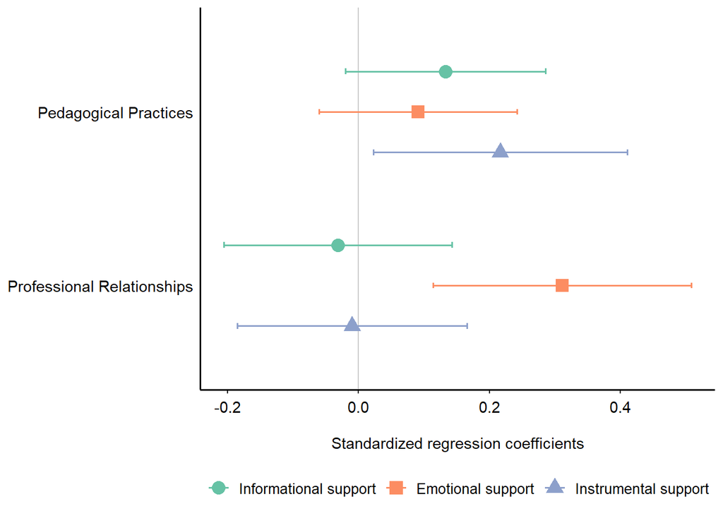

```r
# Get paths

get_paths <- function(fit, model_label) {
  parameterEstimates(fit, ci = TRUE, level = 0.95) %>%
    filter(op == "~", !rhs %in% c("vig2", "vig3")) %>%
    transmute(outcome = lhs,
              predictor = rhs,
              est, ci.lower, ci.upper)}

paths <- (get_paths(fit_sef))

# Labels

paths <- paths %>%
  mutate(
    predictor_label = recode(predictor,
      sef_pea   = "Pedagogical Practices",
      sef_rel   = "Professional Relationships"),
    outcome_label = recode(outcome,
      inf_sup = "Informational support",
      emo_sup = "Emotional support",
      ins_sup = "Instrumental support"),
    outcome_label = factor(outcome_label,
                           levels = c("Informational support",
                                      "Emotional support",
                                      "Instrumental support")))

# Order predictors top to bottom
pred_levels <- c("Pedagogical Practices", "Professional Relationships")

paths$predictor_label <- factor(paths$predictor_label, levels = rev(pred_levels))

# Plot
dodge <- position_dodge(width = 0.7, reverse = TRUE)

plot_forest <- ggplot(paths, aes(x = est, y = predictor_label,
                                 color = outcome_label,
                                 shape = outcome_label)) +
  geom_vline(xintercept = 0, linetype = "solid",
             color = "gray80", linewidth = 0.4) +
  geom_errorbar(aes(xmin = ci.lower, xmax = ci.upper),
                orientation = "y", width = 0.1, linewidth = 0.6,
                position = dodge) +
  geom_point(size = 4, position = dodge) +
  scale_color_brewer(palette = "Set2", name = NULL) +
  scale_shape_manual(values = c(16, 15, 17), name = NULL) +
  labs(x = "\nStandardized regression coefficients", y = NULL) +
  theme_minimal(base_size = 11, base_family = "Arial") +

  theme(
    plot.background  = element_rect(fill = "white", colour = NA),
    panel.background = element_rect(fill = "white", colour = NA),
    legend.position  = "bottom",
    legend.text      = element_text(size = 10),
    panel.grid.major = element_blank(),
    panel.grid.minor = element_blank(),
    axis.line = element_line(colour = "black", linewidth = 0.7, linetype = "solid"),
    axis.text        = element_text(colour = "black", size = 11),
    axis.ticks.x     = element_line(colour = "black")
  )

ggsave("forest_plot_seff.png", plot_forest,
       width = 8, height = 5, dpi = 600, bg = "white")

plot(plot_forest)
```

##### 3.6.4 Controllability (Locus)

```r
model <- '
  inf_sup ~ a1*int_cntrd + a2*con_cntrd + a3*conXint + vig2 + vig3
  emo_sup ~ b1*int_cntrd + b2*con_cntrd + b3*conXint + vig2 + vig3
  ins_sup ~ c1*int_cntrd + c2*con_cntrd + c3*conXint + vig2 + vig3

  inf_sup ~~ emo_sup
  emo_sup ~~ ins_sup
  inf_sup ~~ ins_sup

  # simple slopes, effect of con at int (-1, 0, +1 SD)
  inf_con_l := a2 + a3*(-1)
  inf_con_m := a2 + a3*0
  inf_con_h := a2 + a3*(1)

  emo_con_l := b2 + b3*(-1)
  emo_con_m := b2 + b3*0
  emo_con_h := b2 + b3*(1)

  ins_con_l := c2 + c3*(-1)
  ins_con_m := c2 + c3*0
  ins_con_h := c2 + c3*(1)
'

fit_con <- lavaan::sem(model = model,
                       data = data,
                       missing = "fiml",
                       fixed.x = TRUE,
                       estimator = "MLR",
                       meanstructure = TRUE)

summary(fit_con, rsquare = TRUE, ci = TRUE)
```

```
lavaan 0.6-21 ended normally after 29 iterations

  Estimator                                         ML
  Optimization method                           NLMINB
  Number of model parameters                        24

                                                  Used       Total
  Number of observations                           141         153
  Number of missing patterns                         2

Model Test User Model:
                                              Standard      Scaled
  Test Statistic                                 0.000       0.000
  Degrees of freedom                                 0           0

Parameter Estimates:

  Standard errors                             Sandwich
  Information bread                           Observed
  Observed information based on                Hessian

Regressions:
                   Estimate  Std.Err  z-value  P(>|z|) ci.lower ci.upper
  inf_sup ~
    int_cntrd (a1)    0.199    0.092    2.152    0.031    0.018    0.380
    con_cntrd (a2)    0.053    0.094    0.561    0.575   -0.131    0.236
    conXint   (a3)    0.091    0.050    1.805    0.071   -0.008    0.189
    vig2              0.173    0.223    0.774    0.439   -0.265    0.610
    vig3              0.007    0.224    0.032    0.975   -0.431    0.445
  emo_sup ~
    int_cntrd (b1)   -0.057    0.102   -0.556    0.578   -0.257    0.143
    con_cntrd (b2)    0.148    0.098    1.517    0.129   -0.043    0.339
    conXint   (b3)    0.075    0.038    1.988    0.047    0.001    0.149
    vig2             -0.008    0.244   -0.032    0.975   -0.487    0.471
    vig3              0.214    0.208    1.031    0.302   -0.193    0.622
  ins_sup ~
    int_cntrd (c1)   -0.089    0.100   -0.896    0.370   -0.284    0.106
    con_cntrd (c2)    0.115    0.118    0.978    0.328   -0.116    0.346
    conXint   (c3)    0.082    0.059    1.383    0.167   -0.034    0.198
    vig2             -0.225    0.215   -1.045    0.296   -0.647    0.197
```

[output cut: 25 more lines]

```
    inf_sup           0.059
    emo_sup           0.033
    ins_sup           0.030

Defined Parameters:
                   Estimate  Std.Err  z-value  P(>|z|) ci.lower ci.upper
    inf_con_l        -0.038    0.089   -0.428    0.669   -0.213    0.137
    inf_con_m         0.053    0.094    0.561    0.575   -0.131    0.236
    inf_con_h         0.143    0.121    1.183    0.237   -0.094    0.381
    emo_con_l         0.073    0.088    0.823    0.411   -0.101    0.246
    emo_con_m         0.148    0.098    1.517    0.129   -0.043    0.339
    emo_con_h         0.223    0.119    1.881    0.060   -0.009    0.456
    ins_con_l         0.033    0.109    0.304    0.761   -0.180    0.246
    ins_con_m         0.115    0.118    0.978    0.328   -0.116    0.346
    ins_con_h         0.197    0.151    1.301    0.193   -0.100    0.494
```

Model fit:

```r
fitMeasures(fit_con, c("chisq", "df", "pvalue", "cfi", "srmr", "rmsea"))
```

```
 chisq     df pvalue    cfi   srmr  rmsea
     0      0     NA      1      0      0
```

##### 3.6.5 Forest-Plot: Controllability

```r
# Get paths

get_paths <- function(fit, model_label) {
  parameterEstimates(fit, ci = TRUE, level = 0.95) %>%
    filter(op == "~", !rhs %in% c("vig2", "vig3")) %>%
    transmute(outcome = lhs,
              predictor = rhs,
              est, ci.lower, ci.upper)}

paths <- (get_paths(fit_con))

# Labels

paths <- paths %>%
  mutate(
    predictor_label = recode(predictor,
      con_cntrd   = "Controllability",
      int_cntrd   = "Locus of control",
      conXint   = "Controllability ×\nLocus of control"),
    outcome_label = recode(outcome,
      inf_sup = "Informational support",
      emo_sup = "Emotional support",
      ins_sup = "Instrumental support"),
    outcome_label = factor(outcome_label,
                           levels = c("Informational support",
                                      "Emotional support",
                                      "Instrumental support")))

# Order predictors top to bottom
pred_levels <- c("Controllability", "Locus of control", "Controllability ×\nLocus of control")

paths$predictor_label <- factor(paths$predictor_label, levels = rev(pred_levels))

# Plot
dodge <- position_dodge(width = 0.7, reverse = TRUE)

plot_forest_con <- ggplot(paths, aes(x = est, y = predictor_label,
                                     color = outcome_label,
                                     shape = outcome_label)) +
  geom_vline(xintercept = 0, linetype = "solid",
             color = "gray80", linewidth = 0.4) +
  geom_errorbar(aes(xmin = ci.lower, xmax = ci.upper),
                orientation = "y", width = 0.1, linewidth = 0.6,
                position = dodge) +
  geom_point(size = 4, position = dodge) +
  scale_color_brewer(palette = "Set2", name = NULL) +
  scale_shape_manual(values = c(16, 15, 17), name = NULL) +
  labs(x = "Standardized regression coefficients", y = NULL) +
  theme_minimal(base_size = 11, base_family = "Arial") +

  theme(
    plot.background  = element_rect(fill = "white", colour = NA),
    panel.background = element_rect(fill = "white", colour = NA),
    legend.position  = "top",
    legend.text      = element_text(size = 10),
    panel.grid.major = element_blank(),
    panel.grid.minor = element_blank(),
    axis.line = element_line(colour = "black", linewidth = 0.7, linetype = "solid"),
    axis.text        = element_text(colour = "black", size = 11),
    axis.ticks.x     = element_line(colour = "black")
  )

ggsave("forest_plot_con.png", plot_forest_con,
       width = 8, height = 5, dpi = 600, bg = "white")
```

##### 3.6.6 Stability

```r
model <- '
  inf_sup ~ a1*int_cntrd + a2*sta_cntrd + a3*staXint + vig2 + vig3
  emo_sup ~ b1*int_cntrd + b2*sta_cntrd + b3*staXint + vig2 + vig3
  ins_sup ~ c1*int_cntrd + c2*sta_cntrd + c3*staXint + vig2 + vig3

  inf_sup ~~ emo_sup
  emo_sup ~~ ins_sup
  inf_sup ~~ ins_sup

  # simple slopes, effect of sta at int (-1, 0, +1 SD)
  inf_sta_l := a2 + a3*(-1)
  inf_sta_m := a2 + a3*0
  inf_sta_h := a2 + a3*(1)

  emo_sta_l := b2 + b3*(-1)
  emo_sta_m := b2 + b3*0
  emo_sta_h := b2 + b3*(1)

  ins_sta_l := c2 + c3*(-1)
  ins_sta_m := c2 + c3*0
  ins_sta_h := c2 + c3*(1)
'

fit_sta <- lavaan::sem(model = model,
                       data = data,
                       missing = "fiml",
                       fixed.x = TRUE,
                       estimator = "MLR",
                       meanstructure = TRUE)

summary(fit_sta, rsquare = TRUE, ci = TRUE)
```

```
lavaan 0.6-21 ended normally after 25 iterations

  Estimator                                         ML
  Optimization method                           NLMINB
  Number of model parameters                        24

                                                  Used       Total
  Number of observations                           141         153
  Number of missing patterns                         2

Model Test User Model:
                                              Standard      Scaled
  Test Statistic                                 0.000       0.000
  Degrees of freedom                                 0           0

Parameter Estimates:

  Standard errors                             Sandwich
  Information bread                           Observed
  Observed information based on                Hessian

Regressions:
                   Estimate  Std.Err  z-value  P(>|z|) ci.lower ci.upper
  inf_sup ~
    int_cntrd (a1)    0.178    0.084    2.116    0.034    0.013    0.343
    sta_cntrd (a2)   -0.009    0.077   -0.117    0.907   -0.160    0.142
    staXint   (a3)   -0.097    0.056   -1.737    0.082   -0.207    0.012
    vig2              0.160    0.224    0.715    0.475   -0.279    0.599
    vig3              0.020    0.223    0.089    0.929   -0.418    0.457
  emo_sup ~
    int_cntrd (b1)   -0.044    0.088   -0.498    0.618   -0.215    0.128
    sta_cntrd (b2)    0.052    0.073    0.723    0.470   -0.090    0.195
    staXint   (b3)    0.027    0.048    0.569    0.569   -0.066    0.121
    vig2              0.013    0.246    0.054    0.957   -0.469    0.496
    vig3              0.237    0.210    1.126    0.260   -0.175    0.649
  ins_sup ~
    int_cntrd (c1)   -0.085    0.086   -0.986    0.324   -0.253    0.084
    sta_cntrd (c2)   -0.011    0.088   -0.122    0.903   -0.183    0.162
    staXint   (c3)   -0.170    0.058   -2.947    0.003   -0.283   -0.057
    vig2             -0.235    0.210   -1.121    0.262   -0.646    0.176
```

[output cut: 25 more lines]

```
    inf_sup           0.058
    emo_sup           0.017
    ins_sup           0.053

Defined Parameters:
                   Estimate  Std.Err  z-value  P(>|z|) ci.lower ci.upper
    inf_sta_l         0.088    0.087    1.009    0.313   -0.083    0.259
    inf_sta_m        -0.009    0.077   -0.117    0.907   -0.160    0.142
    inf_sta_h        -0.106    0.103   -1.033    0.302   -0.307    0.095
    emo_sta_l         0.025    0.067    0.377    0.706   -0.106    0.157
    emo_sta_m         0.052    0.073    0.723    0.470   -0.090    0.195
    emo_sta_h         0.080    0.103    0.774    0.439   -0.122    0.282
    ins_sta_l         0.159    0.081    1.959    0.050   -0.000    0.319
    ins_sta_m        -0.011    0.088   -0.122    0.903   -0.183    0.162
    ins_sta_h        -0.181    0.125   -1.449    0.147   -0.425    0.064
```

Model fit:

```r
fitMeasures(fit_sta, c("chisq", "df", "pvalue", "cfi", "srmr", "rmsea"))
```

```
 chisq     df pvalue    cfi   srmr  rmsea
     0      0     NA      1      0      0
```

##### 3.6.7 Forest-Plot: Stability

```r
# Get paths

get_paths <- function(fit, model_label) {
  parameterEstimates(fit, ci = TRUE, level = 0.95) %>%
    filter(op == "~", !rhs %in% c("vig2", "vig3")) %>%
    transmute(outcome = lhs,
              predictor = rhs,
              est, ci.lower, ci.upper)}

paths <- (get_paths(fit_sta))

# Labels

paths <- paths %>%
  mutate(
    predictor_label = recode(predictor,
      sta_cntrd   = "Stability",
      int_cntrd   = "Locus of control",
      staXint   = "Stability ×\nLocus of control"),
    outcome_label = recode(outcome,
      inf_sup = "Informational support",
      emo_sup = "Emotional support",
      ins_sup = "Instrumental support"),
    outcome_label = factor(outcome_label,
                           levels = c("Informational support",
                                      "Emotional support",
                                      "Instrumental support")))

# Order predictors top to bottom
pred_levels <- c("Stability", "Locus of control", "Stability ×\nLocus of control")

paths$predictor_label <- factor(paths$predictor_label, levels = rev(pred_levels))

# Plot
dodge <- position_dodge(width = 0.7, reverse = TRUE)

plot_forest_sta <- ggplot(paths, aes(x = est, y = predictor_label,
                                     color = outcome_label,
                                     shape = outcome_label)) +
  geom_vline(xintercept = 0, linetype = "solid",
             color = "gray80", linewidth = 0.4) +
  geom_errorbar(aes(xmin = ci.lower, xmax = ci.upper),
                orientation = "y", width = 0.1, linewidth = 0.6,
                position = dodge) +
  geom_point(size = 4, position = dodge) +
  scale_color_brewer(palette = "Set2", name = NULL) +
  scale_shape_manual(values = c(16, 15, 17), name = NULL) +
  labs(x = "Standardized regression coefficients", y = NULL) +
  theme_minimal(base_size = 11, base_family = "Arial") +

  theme(
    plot.background  = element_rect(fill = "white", colour = NA),
    panel.background = element_rect(fill = "white", colour = NA),
    legend.position  = "top",
    legend.text      = element_text(size = 10),
    panel.grid.major = element_blank(),
    panel.grid.minor = element_blank(),
    axis.line = element_line(colour = "black", linewidth = 0.7, linetype = "solid"),
    axis.text        = element_text(colour = "black", size = 11),
    axis.ticks.x     = element_line(colour = "black")
  )

ggsave("forest_plot_sta.png", plot_forest_sta,
       width = 8, height = 5, dpi = 600, bg = "white")
```

##### 3.6.8 Forest-Plot: Controllability and Stability

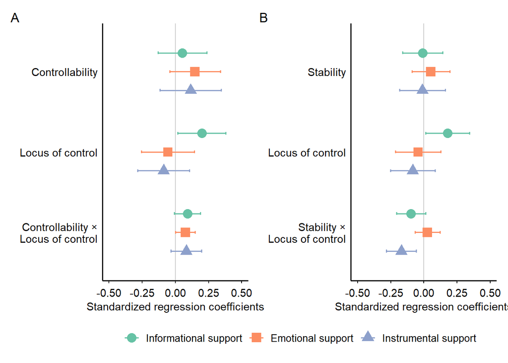

```r
plot_combined <- (plot_forest_con | plot_forest_sta) +
  plot_layout(guides = "collect") +
  plot_annotation(
    tag_levels = "A",
    theme = theme(plot.caption = element_text(hjust = 0.5, size = 11,
                                              family = "Arial"))
  ) &
  theme(legend.position = "bottom") &
  coord_cartesian(xlim = c(-0.5, 0.5))

ggsave("forest_plot_con_sta.png", plot_combined,
       width = 11, height = 5, dpi = 600, bg = "white")

plot(plot_combined)
```

#### 3.7 Descriptives: Vignettes

*What reasons were given for the situation?*

```r
sorted_data <- data_t2 %>%
  dplyr::select(vig, ursache) %>%
  dplyr::arrange(vig)
```

Vignette 1: “General turbulence among students”

```r
sorted_data_vig1 <- sorted_data %>%
  dplyr::filter(vig == 1)

print(sorted_data_vig1$ursache)
```

```
 [1] "Lehrkraft-Lernenden-Beziehung"
 [2] "Unklare Erwartungen auf beiden Seiten (Lehrer-Schüler)"
 [3] "Lernkontext unklar"
 [4] "Mangelndes Classroom-Management"
 [5] "Die Lerngruppe ist nicht auf den Unterricht fokussiert, es fehlt der klare Rahmen."
 [6] "Emotionalität der SuS"
 [7] ""
 [8] "SuS-L-Beziehung (noch) nicht gut"
 [9] "Fehlende Beziehung zu den SuS"
[10] "Die Lerngruppe ist drinnen und bewegt sich kaum. Die laute Kommunikation ist ein Kompensationsventil der Klasse. "
[11] "fehlende Ritualisierung, Arbeitskultur"
[12] "Eine Diagnose ist aufgrund der kargen Beschreibung gar nicht möglich. "
[13] "kurze Aufmerksamkeitsspanne der Lerngruppe"
[14] "Schwierigkeiten in der Beziehungsebene zwischen LAA und Schülern"
[15] "Beziehungsaufbau nicht gelungen ggf. "
```

[output cut: 31 more lines]

Vignette 2: “Only a third work”

```r
sorted_data_vig2 <- sorted_data %>%
  dplyr::filter(vig == 2)

print(sorted_data_vig2$ursache)
```

```
 [1] "Sinnhaftigkeit der Aufgabe unklar"
 [2] "Lernprozess"
 [3] ""
 [4] "Die Aufgabe ist nicht sinnstiftend mit Bezug zur Bedeutsamkeit des Inhaltes angelegt."
 [5] ""
 [6] "Die SUS haben keine ausreichende Gelegenheit gehabt, den Arbeitsauftrag anzunehmen. Die Beschreibung der Situation \"\"stellt einen Arbeitsauftrag\"\", \"\"den die SUS [...] bearbeiten sollen\"\", \"\"zum Arbeiten aufgefordert hat\"\" wirkt insgesamt so, als liege hier eine (zu) starke Lehrer*…
 [7] "Transparenz für den Arbeitsauftrag fehlt: Wozu ist er nötig? Wohin soll er führen?"
 [8] "Schüler Lehrer Beziehung "
 [9] "Die LiV hat keine Verbindlichkeit hergestellt, indem sie deutlich gemacht hat, was mit den Ergebnissen passiert, z.B. dass jeder in der Lage sein muss zu präsentieren, dass diese eingesammelt werden, dass diese benotet werden etc. Die SuS haben daher das Gefühl, dass es egal ist, ob sie die Au…
[10] "Externe Einflüsse auf die Lerngruppe (Klassenarbeit in der nächsten Stunde)"
[11] "Transparenz -> Motivation"
[12] "fehlende Transparenz - Klärung der Frage: Warum sollen wir das machen!"
[13] "Fehlende Passung - Arbeitsauftrag ist für SuS nicht relevant, erkennen Zusammenhang zwischen Gegenstand und Arbeitsauftrag nicht; evtl. Störung der Beziehung innerhalb der Lerngruppe oder zwischen Lerngruppe und LiA"
[14] "Beziehung zwischen LAA und SuS scheint nicht stimmig "
[15] "Das Lernangebot überfordert die SuS massiv"
```

[output cut: 41 more lines]

Vignette 3: “Refusal to change seats”

```r
sorted_data_vig3 <- sorted_data %>%
  dplyr::filter(vig == 3)

print(sorted_data_vig3$ursache)
```

```
 [1] "Schüler*innen-Lehrer*innen-Beziehung"
 [2] "Der Schüler fühlt sich bloßgestellt vor der Klasse, wenn er sich erheben soll, eine Ermahnung seitens des LAA wäre zuerst angebracht."
 [3] "Ich kann dies Frage nicht beantworten, da ich den konstruierten Fall nicht nachvollziehen kann. Grundsätzlich diagnostiziere ich nach Beobachtung. Hier fehlen mir aber wichtige Hinweise im Vorfeld der Störung. sic."
 [4] "ungünstiges Classroom-Management"
 [5] "individuelle Problemlage beim Schüler, die die LiVd sicherlich in der Unterichtsplanung benannt hat; mangelnde Handlungsalternativen zum jetzigen Ausbildungsstand"
 [6] "Über oder Unterforderung"
 [7] ""
 [8] "kein gutes Classroom Management"
 [9] ""
[10] ""
[11] "pubertäres Herausfordern von Grenzsituationen"
[12] "Langeweile in Kombination mit einer typischen Machtkonstellation. "
[13] "Die bereits bestehende Unruhe in der Stunde "
[14] "Individuelles (Fehl)verhalten des störenden Schülers "
[15] "Fehlende Schüleraktivierung"
```

[output cut: 36 more lines]

## References

Richter, D., Kunter, M., Lüdtke, O., Klusmann, U., & Baumert, J. (2011). Soziale unterstützung beim berufseinstieg ins lehramt. *Zeitschrift Für Erziehungswissenschaft*, *14*(1), 35–59.

*Soziale unterstützung bei der krankheitsbewältigung: Die berliner social support skalen (BSSS) soziale unterstützung bei der krankheitsbewältigung: Die berliner social support skalen (BSSS)* (2; pp. 73–82). (2003). Hogrefe Verlag.

Steinsmeier, J., Kammer, D., Pelster, A., & Niketta, R. (1985). Attributionsstil und bewertung als risikofaktoren der depressiven reaktion. *Bielefelder Arbeiten Zur Sozialpsychologie*.

Tickell, R. M., & Klassen, R. M. (2024). Developing the teacher mentoring self-efficacy scale (TMSES) using the delphi method and exploratory factor analysis. *Teaching and Teacher Education*, *139*, 104452.